# Risk Factor Analysis

## Outcome Variable

**Outcome Variable:** pers_wast

## Predictor Variables

**Intervention Variable:** predfeed36

**Adjustment Set:**

- arm
- sex
- month
- brthmon
- W_mage
- meducyrs
- feducyrs
- hhwealth_quart
- hfoodsec
- W_mhtcm
- vagbrth
- W_birthwt
- W_birthlen
- W_nrooms
- W_parity
- impfloor
- impsan
- safeh20
- delta_W_mage
- delta_meducyrs
- delta_feducyrs
- delta_hhwealth_quart
- delta_hfoodsec
- delta_W_mhtcm
- delta_vagbrth
- delta_W_birthwt
- delta_W_birthlen
- delta_W_nrooms
- delta_W_parity
- delta_impfloor
- delta_impsan
- delta_safeh20

## Stratifying Variables

The analysis was stratified on these variable(s):

- agecat
- studyid
- country

## Data Summary

| agecat | studyid | country | predfeed36 | pers_wast | n_cell | n |
| --- | --- | --- | --- | --- | --- | --- |
| 0-24 months | ki0047075b-MAL-ED | BANGLADESH | 0 | 0 | 110 | 247 |
| 0-24 months | ki0047075b-MAL-ED | BANGLADESH | 0 | 1 | 6 | 247 |
| 0-24 months | ki0047075b-MAL-ED | BANGLADESH | 1 | 0 | 124 | 247 |
| 0-24 months | ki0047075b-MAL-ED | BANGLADESH | 1 | 1 | 7 | 247 |
| 0-24 months | ki0047075b-MAL-ED | BRAZIL | 0 | 0 | 178 | 217 |
| 0-24 months | ki0047075b-MAL-ED | BRAZIL | 0 | 1 | 1 | 217 |
| 0-24 months | ki0047075b-MAL-ED | BRAZIL | 1 | 0 | 37 | 217 |
| 0-24 months | ki0047075b-MAL-ED | BRAZIL | 1 | 1 | 1 | 217 |
| 0-24 months | ki0047075b-MAL-ED | INDIA | 0 | 0 | 200 | 241 |
| 0-24 months | ki0047075b-MAL-ED | INDIA | 0 | 1 | 21 | 241 |
| 0-24 months | ki0047075b-MAL-ED | INDIA | 1 | 0 | 20 | 241 |
| 0-24 months | ki0047075b-MAL-ED | INDIA | 1 | 1 | 0 | 241 |
| 0-24 months | ki0047075b-MAL-ED | NEPAL | 0 | 0 | 202 | 238 |
| 0-24 months | ki0047075b-MAL-ED | NEPAL | 0 | 1 | 4 | 238 |
| 0-24 months | ki0047075b-MAL-ED | NEPAL | 1 | 0 | 32 | 238 |
| 0-24 months | ki0047075b-MAL-ED | NEPAL | 1 | 1 | 0 | 238 |
| 0-24 months | ki0047075b-MAL-ED | PERU | 0 | 0 | 155 | 282 |
| 0-24 months | ki0047075b-MAL-ED | PERU | 0 | 1 | 0 | 282 |
| 0-24 months | ki0047075b-MAL-ED | PERU | 1 | 0 | 126 | 282 |
| 0-24 months | ki0047075b-MAL-ED | PERU | 1 | 1 | 1 | 282 |
| 0-24 months | ki0047075b-MAL-ED | SOUTH AFRICA | 0 | 0 | 268 | 273 |
| 0-24 months | ki0047075b-MAL-ED | SOUTH AFRICA | 0 | 1 | 2 | 273 |
| 0-24 months | ki0047075b-MAL-ED | SOUTH AFRICA | 1 | 0 | 3 | 273 |
| 0-24 months | ki0047075b-MAL-ED | SOUTH AFRICA | 1 | 1 | 0 | 273 |
| 0-24 months | ki0047075b-MAL-ED | TANZANIA, UNITED REPUBLIC OF | 0 | 0 | 251 | 253 |
| 0-24 months | ki0047075b-MAL-ED | TANZANIA, UNITED REPUBLIC OF | 0 | 1 | 0 | 253 |
| 0-24 months | ki0047075b-MAL-ED | TANZANIA, UNITED REPUBLIC OF | 1 | 0 | 2 | 253 |
| 0-24 months | ki0047075b-MAL-ED | TANZANIA, UNITED REPUBLIC OF | 1 | 1 | 0 | 253 |
| 0-24 months | ki1000109-EE | PAKISTAN | 0 | 0 | 268 | 744 |
| 0-24 months | ki1000109-EE | PAKISTAN | 0 | 1 | 26 | 744 |

[output cut: 106 more lines]

The following strata were considered:

- agecat: 0-24 months, studyid: ki0047075b-MAL-ED, country: BANGLADESH
- agecat: 0-24 months, studyid: ki0047075b-MAL-ED, country: BRAZIL
- agecat: 0-24 months, studyid: ki0047075b-MAL-ED, country: INDIA
- agecat: 0-24 months, studyid: ki0047075b-MAL-ED, country: NEPAL
- agecat: 0-24 months, studyid: ki0047075b-MAL-ED, country: PERU
- agecat: 0-24 months, studyid: ki0047075b-MAL-ED, country: SOUTH AFRICA
- agecat: 0-24 months, studyid: ki0047075b-MAL-ED, country: TANZANIA, UNITED REPUBLIC OF
- agecat: 0-24 months, studyid: ki1000109-EE, country: PAKISTAN
- agecat: 0-24 months, studyid: ki1000304b-SAS-FoodSuppl, country: INDIA
- agecat: 0-24 months, studyid: ki1113344-GMS-Nepal, country: NEPAL
- agecat: 0-24 months, studyid: ki1148112-LCNI-5, country: MALAWI
- agecat: 0-24 months, studyid: kiGH5241-JiVitA-3, country: BANGLADESH
- agecat: 0-24 months, studyid: kiGH5241-JiVitA-4, country: BANGLADESH
- agecat: 0-6 months, studyid: ki0047075b-MAL-ED, country: BANGLADESH
- agecat: 0-6 months, studyid: ki0047075b-MAL-ED, country: BRAZIL
- agecat: 0-6 months, studyid: ki0047075b-MAL-ED, country: INDIA
- agecat: 0-6 months, studyid: ki0047075b-MAL-ED, country: NEPAL
- agecat: 0-6 months, studyid: ki0047075b-MAL-ED, country: PERU
- agecat: 0-6 months, studyid: ki0047075b-MAL-ED, country: SOUTH AFRICA
- agecat: 0-6 months, studyid: ki0047075b-MAL-ED, country: TANZANIA, UNITED REPUBLIC OF
- agecat: 0-6 months, studyid: ki1000109-EE, country: PAKISTAN
- agecat: 0-6 months, studyid: ki1113344-GMS-Nepal, country: NEPAL
- agecat: 6-24 months, studyid: ki0047075b-MAL-ED, country: BANGLADESH
- agecat: 6-24 months, studyid: ki0047075b-MAL-ED, country: BRAZIL
- agecat: 6-24 months, studyid: ki0047075b-MAL-ED, country: INDIA
- agecat: 6-24 months, studyid: ki0047075b-MAL-ED, country: NEPAL
- agecat: 6-24 months, studyid: ki0047075b-MAL-ED, country: PERU
- agecat: 6-24 months, studyid: ki0047075b-MAL-ED, country: SOUTH AFRICA
- agecat: 6-24 months, studyid: ki0047075b-MAL-ED, country: TANZANIA, UNITED REPUBLIC OF
- agecat: 6-24 months, studyid: ki1000109-EE, country: PAKISTAN
- agecat: 6-24 months, studyid: ki1000304b-SAS-FoodSuppl, country: INDIA
- agecat: 6-24 months, studyid: ki1113344-GMS-Nepal, country: NEPAL
- agecat: 6-24 months, studyid: ki1148112-LCNI-5, country: MALAWI
- agecat: 6-24 months, studyid: kiGH5241-JiVitA-4, country: BANGLADESH

### Dropped Strata

Some strata were dropped due to rare outcomes:

- agecat: 0-24 months, studyid: ki0047075b-MAL-ED, country: BRAZIL
- agecat: 0-24 months, studyid: ki0047075b-MAL-ED, country: INDIA
- agecat: 0-24 months, studyid: ki0047075b-MAL-ED, country: NEPAL
- agecat: 0-24 months, studyid: ki0047075b-MAL-ED, country: PERU
- agecat: 0-24 months, studyid: ki0047075b-MAL-ED, country: SOUTH AFRICA
- agecat: 0-24 months, studyid: ki0047075b-MAL-ED, country: TANZANIA, UNITED REPUBLIC OF
- agecat: 0-24 months, studyid: ki1000304b-SAS-FoodSuppl, country: INDIA
- agecat: 0-24 months, studyid: ki1148112-LCNI-5, country: MALAWI
- agecat: 0-6 months, studyid: ki0047075b-MAL-ED, country: BANGLADESH
- agecat: 0-6 months, studyid: ki0047075b-MAL-ED, country: BRAZIL
- agecat: 0-6 months, studyid: ki0047075b-MAL-ED, country: INDIA
- agecat: 0-6 months, studyid: ki0047075b-MAL-ED, country: NEPAL
- agecat: 0-6 months, studyid: ki0047075b-MAL-ED, country: PERU
- agecat: 0-6 months, studyid: ki0047075b-MAL-ED, country: SOUTH AFRICA
- agecat: 0-6 months, studyid: ki0047075b-MAL-ED, country: TANZANIA, UNITED REPUBLIC OF
- agecat: 6-24 months, studyid: ki0047075b-MAL-ED, country: BRAZIL
- agecat: 6-24 months, studyid: ki0047075b-MAL-ED, country: INDIA
- agecat: 6-24 months, studyid: ki0047075b-MAL-ED, country: NEPAL
- agecat: 6-24 months, studyid: ki0047075b-MAL-ED, country: PERU
- agecat: 6-24 months, studyid: ki0047075b-MAL-ED, country: SOUTH AFRICA
- agecat: 6-24 months, studyid: ki0047075b-MAL-ED, country: TANZANIA, UNITED REPUBLIC OF
- agecat: 6-24 months, studyid: ki1000304b-SAS-FoodSuppl, country: INDIA
- agecat: 6-24 months, studyid: ki1148112-LCNI-5, country: MALAWI

## Methods Detail

We’re interested in the causal parameters $E[Y_a]$ for all values of $a \in \mathcal{A}$. These parameters represent the mean outcome if, possibly contrary to fact, we intervened to set all units to have $A=a$. Under the randomization and positivity assumptions, these are identified by the statistical parameters $\psi_a=E_W[E_{Y|A,W}(Y|A=a,W)]$. In addition, we’re interested in the mean of $Y$, $E[Y]$ under no intervention (the observed mean). We will estimate these parameters by using SuperLearner to fit the relevant likelihood factors – $E_{Y|A,W}(Y|A=a,W)$ and $p(A=a|W)$, and then updating our likelihood fit using a joint TMLE.

For unadjusted analyses ($W=\{\}$), initial likelihoods were estimated using Lrnr_glm to estimate the simple $E(Y|A)$ and Lrnr_mean to estimate $p(A)$. For adjusted analyses, a small library containing Lrnr_glmnet, Lrnr_xgboost, and Lrnr_mean was used.

Having estimated these parameters, we will then use the delta method to estimate relative risks and attributable risks relative to a prespecified baseline level of $A$.

# Results Detail

## Results Plots

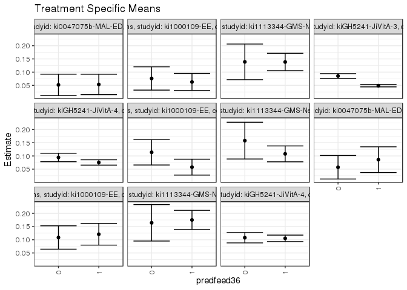

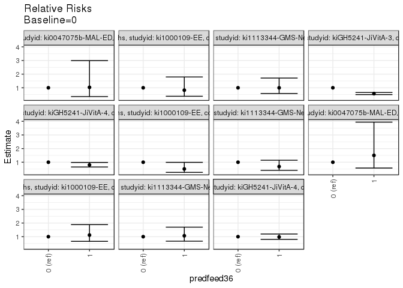

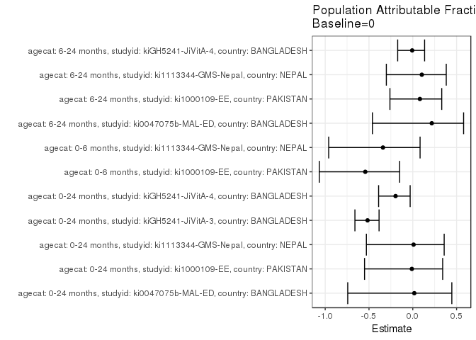

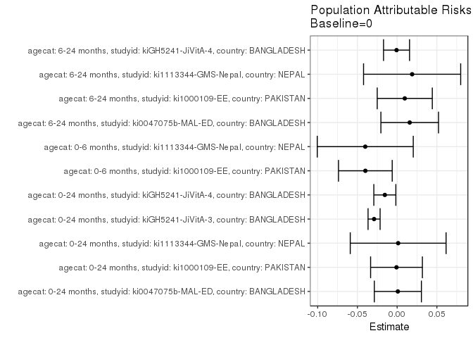

## Results Table

### Parameter: TSM

| agecat | studyid | country | intervention_level | baseline_level | estimate | ci_lower | ci_upper |
| --- | --- | --- | --- | --- | --- | --- | --- |
| 0-24 months | ki0047075b-MAL-ED | BANGLADESH | 0 | NA | 0.0517241 | 0.0113397 | 0.0921086 |
| 0-24 months | ki0047075b-MAL-ED | BANGLADESH | 1 | NA | 0.0534351 | 0.0148445 | 0.0920258 |
| 0-24 months | ki1000109-EE | PAKISTAN | 0 | NA | 0.0760764 | 0.0319987 | 0.1201542 |
| 0-24 months | ki1000109-EE | PAKISTAN | 1 | NA | 0.0627963 | 0.0304117 | 0.0951809 |
| 0-24 months | ki1113344-GMS-Nepal | NEPAL | 0 | NA | 0.1388603 | 0.0713805 | 0.2063402 |
| 0-24 months | ki1113344-GMS-Nepal | NEPAL | 1 | NA | 0.1384587 | 0.1055673 | 0.1713500 |
| 0-24 months | kiGH5241-JiVitA-3 | BANGLADESH | 0 | NA | 0.0852179 | 0.0761411 | 0.0942948 |
| 0-24 months | kiGH5241-JiVitA-3 | BANGLADESH | 1 | NA | 0.0487575 | 0.0442236 | 0.0532914 |
| 0-24 months | kiGH5241-JiVitA-4 | BANGLADESH | 0 | NA | 0.0942333 | 0.0781983 | 0.1102683 |
| 0-24 months | kiGH5241-JiVitA-4 | BANGLADESH | 1 | NA | 0.0753863 | 0.0652623 | 0.0855103 |
| 0-6 months | ki1000109-EE | PAKISTAN | 0 | NA | 0.1137718 | 0.0657376 | 0.1618059 |
| 0-6 months | ki1000109-EE | PAKISTAN | 1 | NA | 0.0576056 | 0.0275409 | 0.0876703 |
| 0-6 months | ki1113344-GMS-Nepal | NEPAL | 0 | NA | 0.1580145 | 0.0884258 | 0.2276031 |
| 0-6 months | ki1113344-GMS-Nepal | NEPAL | 1 | NA | 0.1078676 | 0.0777957 | 0.1379395 |
| 6-24 months | ki0047075b-MAL-ED | BANGLADESH | 0 | NA | 0.0571429 | 0.0126499 | 0.1016358 |
| 6-24 months | ki0047075b-MAL-ED | BANGLADESH | 1 | NA | 0.0859375 | 0.0372793 | 0.1345957 |
| 6-24 months | ki1000109-EE | PAKISTAN | 0 | NA | 0.1085410 | 0.0643398 | 0.1527421 |
| 6-24 months | ki1000109-EE | PAKISTAN | 1 | NA | 0.1208806 | 0.0797243 | 0.1620369 |
| 6-24 months | ki1113344-GMS-Nepal | NEPAL | 0 | NA | 0.1641910 | 0.0951589 | 0.2332232 |
| 6-24 months | ki1113344-GMS-Nepal | NEPAL | 1 | NA | 0.1750293 | 0.1387677 | 0.2112909 |
| 6-24 months | kiGH5241-JiVitA-4 | BANGLADESH | 0 | NA | 0.1077348 | 0.0881340 | 0.1273356 |
| 6-24 months | kiGH5241-JiVitA-4 | BANGLADESH | 1 | NA | 0.1053244 | 0.0930027 | 0.1176460 |

### Parameter: E(Y)

| agecat | studyid | country | intervention_level | baseline_level | estimate | ci_lower | ci_upper |
| --- | --- | --- | --- | --- | --- | --- | --- |
| 0-24 months | ki0047075b-MAL-ED | BANGLADESH | NA | NA | 0.0526316 | 0.0247278 | 0.0805354 |
| 0-24 months | ki1000109-EE | PAKISTAN | NA | NA | 0.0752688 | 0.0484230 | 0.1021146 |
| 0-24 months | ki1113344-GMS-Nepal | NEPAL | NA | NA | 0.1401515 | 0.1105133 | 0.1697898 |
| 0-24 months | kiGH5241-JiVitA-3 | BANGLADESH | NA | NA | 0.0561929 | 0.0517926 | 0.0605933 |
| 0-24 months | kiGH5241-JiVitA-4 | BANGLADESH | NA | NA | 0.0787472 | 0.0695071 | 0.0879873 |
| 0-6 months | ki1000109-EE | PAKISTAN | NA | NA | 0.0737705 | 0.0469540 | 0.1005870 |
| 0-6 months | ki1113344-GMS-Nepal | NEPAL | NA | NA | 0.1178782 | 0.0898370 | 0.1459194 |
| 6-24 months | ki0047075b-MAL-ED | BANGLADESH | NA | NA | 0.0729614 | 0.0394957 | 0.1064270 |
| 6-24 months | ki1000109-EE | PAKISTAN | NA | NA | 0.1181319 | 0.0849287 | 0.1513351 |
| 6-24 months | ki1113344-GMS-Nepal | NEPAL | NA | NA | 0.1830443 | 0.1497431 | 0.2163456 |
| 6-24 months | kiGH5241-JiVitA-4 | BANGLADESH | NA | NA | 0.1069757 | 0.0954392 | 0.1185121 |

### Parameter: RR

| agecat | studyid | country | intervention_level | baseline_level | estimate | ci_lower | ci_upper |
| --- | --- | --- | --- | --- | --- | --- | --- |
| 0-24 months | ki0047075b-MAL-ED | BANGLADESH | 0 | 0 | 1.0000000 | 1.0000000 | 1.0000000 |
| 0-24 months | ki0047075b-MAL-ED | BANGLADESH | 1 | 0 | 1.0330789 | 0.3566438 | 2.9924868 |
| 0-24 months | ki1000109-EE | PAKISTAN | 0 | 0 | 1.0000000 | 1.0000000 | 1.0000000 |
| 0-24 months | ki1000109-EE | PAKISTAN | 1 | 0 | 0.8254370 | 0.3799564 | 1.7932220 |
| 0-24 months | ki1113344-GMS-Nepal | NEPAL | 0 | 0 | 1.0000000 | 1.0000000 | 1.0000000 |
| 0-24 months | ki1113344-GMS-Nepal | NEPAL | 1 | 0 | 0.9971073 | 0.5805451 | 1.7125681 |
| 0-24 months | kiGH5241-JiVitA-3 | BANGLADESH | 0 | 0 | 1.0000000 | 1.0000000 | 1.0000000 |
| 0-24 months | kiGH5241-JiVitA-3 | BANGLADESH | 1 | 0 | 0.5721510 | 0.4995366 | 0.6553209 |
| 0-24 months | kiGH5241-JiVitA-4 | BANGLADESH | 0 | 0 | 1.0000000 | 1.0000000 | 1.0000000 |
| 0-24 months | kiGH5241-JiVitA-4 | BANGLADESH | 1 | 0 | 0.7999964 | 0.6498600 | 0.9848185 |
| 0-6 months | ki1000109-EE | PAKISTAN | 0 | 0 | 1.0000000 | 1.0000000 | 1.0000000 |
| 0-6 months | ki1000109-EE | PAKISTAN | 1 | 0 | 0.5063262 | 0.2590132 | 0.9897806 |
| 0-6 months | ki1113344-GMS-Nepal | NEPAL | 0 | 0 | 1.0000000 | 1.0000000 | 1.0000000 |
| 0-6 months | ki1113344-GMS-Nepal | NEPAL | 1 | 0 | 0.6826438 | 0.4059947 | 1.1478044 |
| 6-24 months | ki0047075b-MAL-ED | BANGLADESH | 0 | 0 | 1.0000000 | 1.0000000 | 1.0000000 |
| 6-24 months | ki0047075b-MAL-ED | BANGLADESH | 1 | 0 | 1.5039062 | 0.5742655 | 3.9384816 |
| 6-24 months | ki1000109-EE | PAKISTAN | 0 | 0 | 1.0000000 | 1.0000000 | 1.0000000 |
| 6-24 months | ki1000109-EE | PAKISTAN | 1 | 0 | 1.1136864 | 0.6585828 | 1.8832826 |
| 6-24 months | ki1113344-GMS-Nepal | NEPAL | 0 | 0 | 1.0000000 | 1.0000000 | 1.0000000 |
| 6-24 months | ki1113344-GMS-Nepal | NEPAL | 1 | 0 | 1.0660103 | 0.6691199 | 1.6983173 |
| 6-24 months | kiGH5241-JiVitA-4 | BANGLADESH | 0 | 0 | 1.0000000 | 1.0000000 | 1.0000000 |
| 6-24 months | kiGH5241-JiVitA-4 | BANGLADESH | 1 | 0 | 0.9776262 | 0.8016197 | 1.1922773 |

### Parameter: PAR

| agecat | studyid | country | intervention_level | baseline_level | estimate | ci_lower | ci_upper |
| --- | --- | --- | --- | --- | --- | --- | --- |
| 0-24 months | ki0047075b-MAL-ED | BANGLADESH | 0 | NA | 0.0009074 | -0.0287180 | 0.0305328 |
| 0-24 months | ki1000109-EE | PAKISTAN | 0 | NA | -0.0008076 | -0.0333974 | 0.0317822 |
| 0-24 months | ki1113344-GMS-Nepal | NEPAL | 0 | NA | 0.0012912 | -0.0590188 | 0.0616012 |
| 0-24 months | kiGH5241-JiVitA-3 | BANGLADESH | 0 | NA | -0.0290250 | -0.0366070 | -0.0214431 |
| 0-24 months | kiGH5241-JiVitA-4 | BANGLADESH | 0 | NA | -0.0154861 | -0.0293442 | -0.0016280 |
| 0-6 months | ki1000109-EE | PAKISTAN | 0 | NA | -0.0400013 | -0.0738070 | -0.0061955 |
| 0-6 months | ki1113344-GMS-Nepal | NEPAL | 0 | NA | -0.0401363 | -0.1005611 | 0.0202886 |
| 6-24 months | ki0047075b-MAL-ED | BANGLADESH | 0 | NA | 0.0158185 | -0.0204494 | 0.0520865 |
| 6-24 months | ki1000109-EE | PAKISTAN | 0 | NA | 0.0095909 | -0.0250731 | 0.0442549 |
| 6-24 months | ki1113344-GMS-Nepal | NEPAL | 0 | NA | 0.0188533 | -0.0422783 | 0.0799849 |
| 6-24 months | kiGH5241-JiVitA-4 | BANGLADESH | 0 | NA | -0.0007591 | -0.0171262 | 0.0156080 |

### Parameter: PAF

| agecat | studyid | country | intervention_level | baseline_level | estimate | ci_lower | ci_upper |
| --- | --- | --- | --- | --- | --- | --- | --- |
| 0-24 months | ki0047075b-MAL-ED | BANGLADESH | 0 | NA | 0.0172414 | -0.7424613 | 0.4457182 |
| 0-24 months | ki1000109-EE | PAKISTAN | 0 | NA | -0.0107299 | -0.5507288 | 0.3412291 |
| 0-24 months | ki1113344-GMS-Nepal | NEPAL | 0 | NA | 0.0092127 | -0.5297297 | 0.3582792 |
| 0-24 months | kiGH5241-JiVitA-3 | BANGLADESH | 0 | NA | -0.5165242 | -0.6605654 | -0.3849775 |
| 0-24 months | kiGH5241-JiVitA-4 | BANGLADESH | 0 | NA | -0.1966557 | -0.3900768 | -0.0301480 |
| 0-6 months | ki1000109-EE | PAKISTAN | 0 | NA | -0.5422393 | -1.0677109 | -0.1503069 |
| 0-6 months | ki1113344-GMS-Nepal | NEPAL | 0 | NA | -0.3404893 | -0.9600661 | 0.0832393 |
| 6-24 months | ki0047075b-MAL-ED | BANGLADESH | 0 | NA | 0.2168067 | -0.4609385 | 0.5801386 |
| 6-24 months | ki1000109-EE | PAKISTAN | 0 | NA | 0.0811882 | -0.2609467 | 0.3304911 |
| 6-24 months | ki1113344-GMS-Nepal | NEPAL | 0 | NA | 0.1029985 | -0.3018609 | 0.3819526 |
| 6-24 months | kiGH5241-JiVitA-4 | BANGLADESH | 0 | NA | -0.0070964 | -0.1723699 | 0.1348779 |